# Praca domowa 2

Karolina Strzelecka

## Dane

Dane wykorzystane w Pracy domowej 2 dotyczą wyników egzaminów z 3 umiejętności: czytania, pisania i operacji matematycznych. Dodatkowo dostępne są podstawowe informacje o studentach i ich rodzicach. Opis wszystkich kolumn znajduje się również w pliku `README.md`.

| Zmienna | Opis |
| --- | --- |
| **gender** | płeć |
| **race.ethnicity** | pochodzenie etniczne |
| **parental.level.of.education** | wykształcenie rodziców |
| **lunch** | jaki obiad jedli uczniowie w dniu egzaminu |
| **test.preparation.course** | czy uczeń odbył kurs przygotowujący |
| **math.score** | wynik egzaminu z matematyki |
| **reading.score** | wynik egzaminu z czytania |
| **writing.score** | wynik egzaminu z pisania |

## Zadanie 1

Jak wyglądają rozkłady wyników uczniów z trzech przedmiotów (matematyka, czytanie, pisanie)?

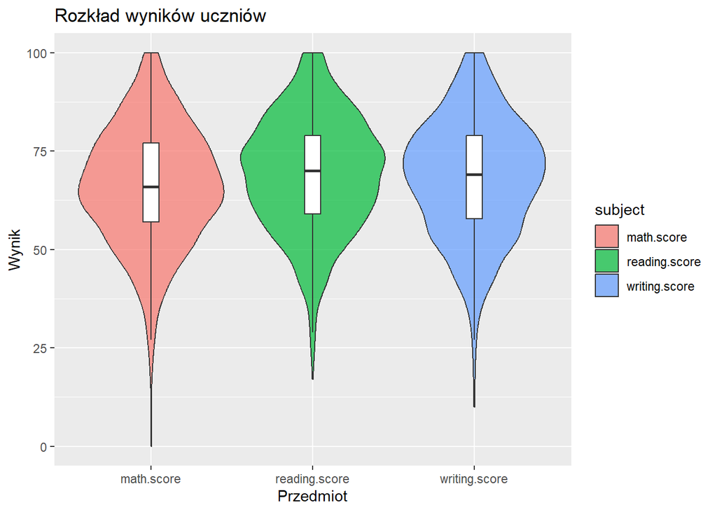

```r
ggplot(dane1, aes(x = subject, y = score, fill = subject)) +
  geom_violin(alpha = 0.7) +
  geom_boxplot(width = 0.1, fill = "white", outlier.shape = NA) +
  labs(title = "Rozkład wyników uczniów",
       x = "Przedmiot", y = "Wynik")
```

**Komentarz:** Najniższe wyniki uczniowie mieli z matematyki - procent osiągnięty przez najwikszą grupę uczniów jest najniższy z matematyki(nieco powyżej 60%), póżniej pisanie i czytanie. Wyniki z każdego przedmiotu osiągają prawie pełną skalę (z tym,że z matematyki sięgają najdalej w dół) środkowa część wyników również jest najniższa z matematyki, z czytania i pisania bardzo zbliżona).

## Zadanie 2

Czy istnieje zauważalna różnica w wynikach między uczniami i uczennicami?

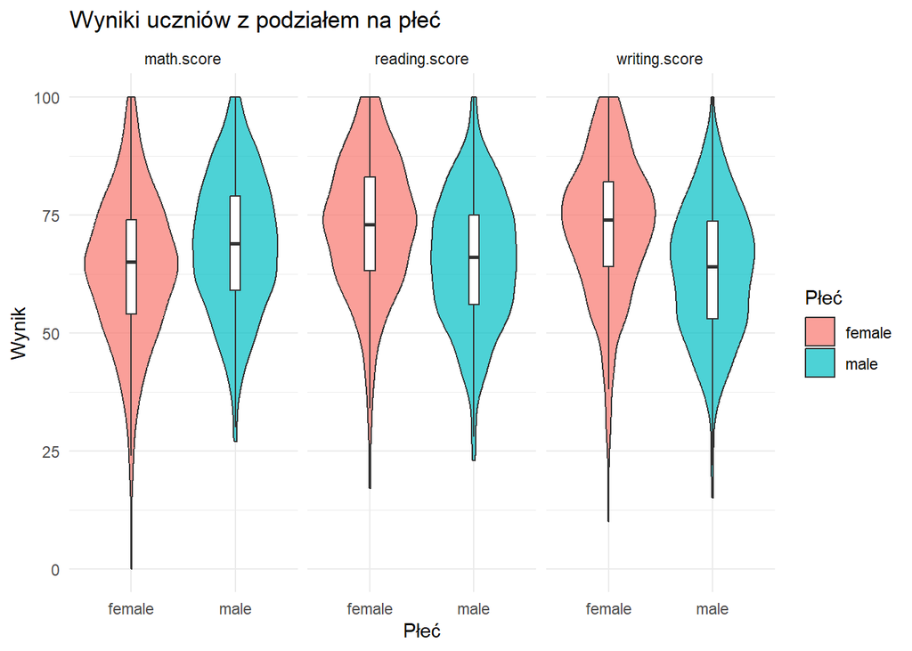

```r
ggplot(dane1, aes(x = gender, y = score, fill = gender)) +
  geom_violin(alpha = 0.7) +
  geom_boxplot(width = 0.1, fill = "white", outlier.shape = NA) +
  facet_wrap(~subject) +
  labs(
    title = "Wyniki uczniów z podziałem na płeć",
    x = "Płeć",
    y = "Wynik",
    fill = "Płeć"
  ) +
  theme_minimal()
```

**Komentarz:** Wyniki dziewczyn z czytania i pisania są wyższe niż chłopców - wykresy są “wyżej” co oznacza że heneralnie osiągane wyniki były wyższe. Dodatkowo środkowa część wyników z tych przedmiotów była wyższa oraz procent osiągnięty przez największą grupę osób. Z matematyki jest odwrotnie.

## Zadanie 3

Czy uczniowie, którzy ukończyli kurs przygotowawczy, osiągają lepsze wyniki niż pozostali?

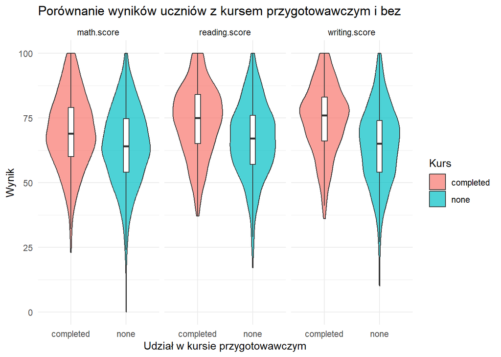

```r
  ggplot(dane1, aes(x = test.preparation.course, y = score, fill = test.preparation.course)) +
    geom_violin(alpha = 0.7) +
    geom_boxplot(width = 0.1, fill = "white", outlier.shape = NA) +
    facet_wrap(~subject) +
    labs(
      title = "Porównanie wyników uczniów z kursem przygotowawczym i bez",
      x = "Udział w kursie przygotowawczym",
      y = "Wynik",
      fill = "Kurs"
    ) +
    theme_minimal()
```

**Komentarz:** Wyraźnie wyniki uczniów po przygotowaniu są wyższe. Z każdego przedmiotu najniższy wynik ucznia po przygotowaniu jest wyższy niż ucznia bez. Co ważne procent osiągnięty przez największą liczbę uczniów także jest wyższy. Dodatkowo dla każdego przedmiotu wyniki osiągnięte przez środkową część uczniów także są wyższe. w zasadzie całę wykresy uczniów z przygotowaniem są “wyżej” z każdego przedmiotu czyli ogólnie po przygotowaniu są osiągane wyższe wyniki.

## Zadanie 4

Jaki jest związek między poziomem wykształcenia rodziców a średnimi wynikami uczniów?

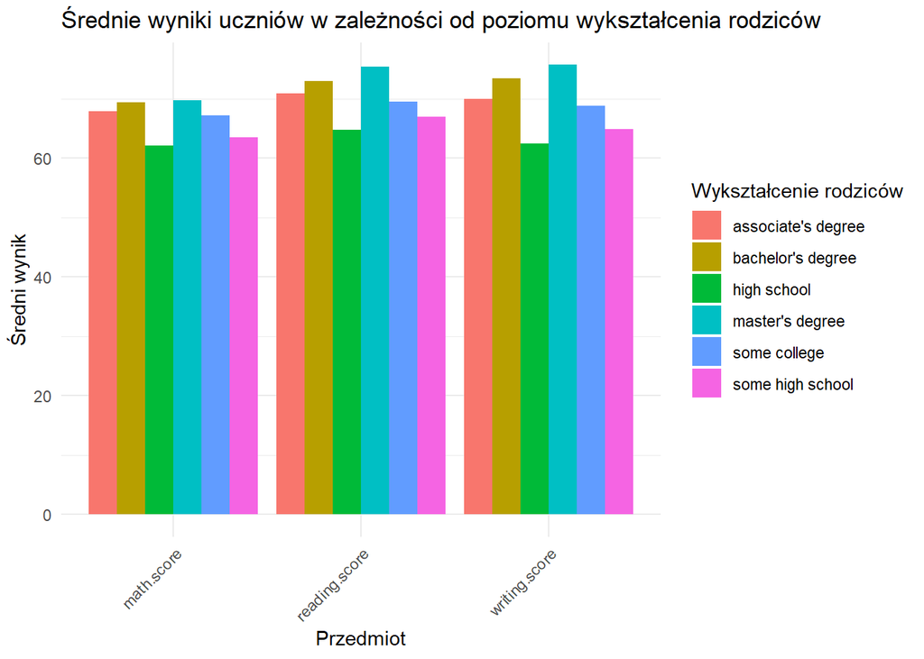

```r
srednie <- dane1 %>%
  group_by(parental.level.of.education, subject) %>%
  summarise(
    sredni_wynik = mean(score, na.rm = TRUE),
    .groups = "drop"
  )


ggplot(srednie, aes(x = subject, y = sredni_wynik, fill = parental.level.of.education)) +
  geom_col(position = "dodge") +
  labs(
    title = "Średnie wyniki uczniów w zależności od poziomu wykształcenia rodziców",
    x = "Przedmiot",
    y = "Średni wynik",
    fill = "Wykształcenie rodziców"
  ) +
  theme_minimal() +
  theme(axis.text.x = element_text(angle = 45, hjust = 1))
```

**Komentarz:** Ogólnie: średnie wyniki uczniów, którzy mają wykształcenie “high school” są najniższe.Póżniej w każdym przedmiocie mamy po kolei: “some high school”, ” some college”, associate’s degree”, ” bachelor’s degree”, ” mastrer,s degree”. Widać zatem zdecydowaną zależność między wykształceniem rodziców a średnimi wynikami uczniów.

## Zadanie 5

Czy płeć i wykształcenie rodzica wpływa na wynik z matematyki?

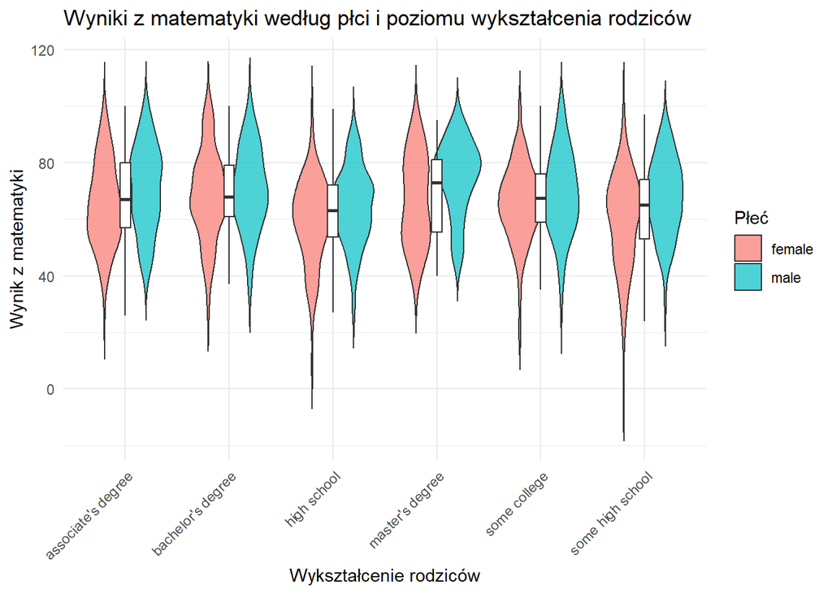

```r
ggplot(df, aes(x = parental.level.of.education, y = math.score, fill = gender)) +
  geom_violin(trim = FALSE, alpha = 0.7, position = position_dodge(width = 0.8)) +
  geom_boxplot(width = 0.1, fill = "white", outlier.shape = NA, position = position_dodge(width = 0.8)) +
  labs(
    title = "Wyniki z matematyki według płci i poziomu wykształcenia rodziców",
    x = "Wykształcenie rodziców",
    y = "Wynik z matematyki",
    fill = "Płeć"
  ) +
  theme_minimal() +
  theme(axis.text.x = element_text(angle = 45, hjust = 1))
```

**Komentarz:** Wygląda na to, że tak… Dla każdego stopnia wykształcenia większa część wyników była wyższa dla chłopców niż dziewczyn jednak te róznice nie są duże. Z poprzedniego wykresu wiemy że wykształcenie rodzica wpływa na średni wynik uczniów, natomiast tutaj dokładniej widac ten rozkład dla matematyki. Kształty wykresów są podobne, natomiast przesunięte w pionie żwiadczą , że ogólnie wyniki są niższe np dla “high school”. Także środkowe wyniki są najniższe dla tej grupy. Najciekawszym rozkładem jest rozkład dla “mastrer’s degree” - wyróżnia się spośród pozostałych - tam procent osiągnięty przez największą grupę uczniów jest zdecydowanie wyższy dla chlópców niż dziewczyn.

## Zadanie 6

Czy istnieje zależność między wynikami z matematyki a wynikami z czytania lub pisania?

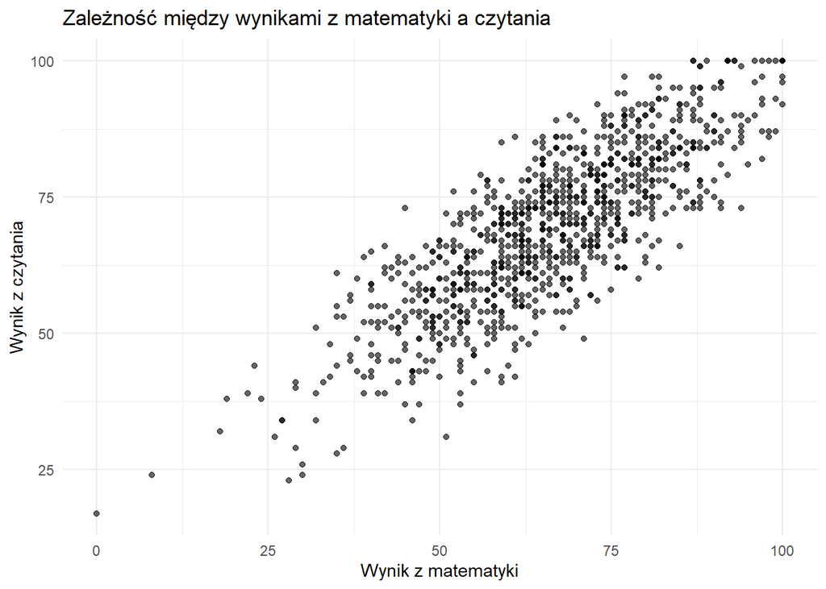

```r
ggplot(df, aes(x = math.score, y = reading.score)) +
  geom_point(alpha = 0.6) +
  labs(
    title = "Zależność między wynikami z matematyki a czytania",
    x = "Wynik z matematyki",
    y = "Wynik z czytania"
  ) +
  theme_minimal()
```

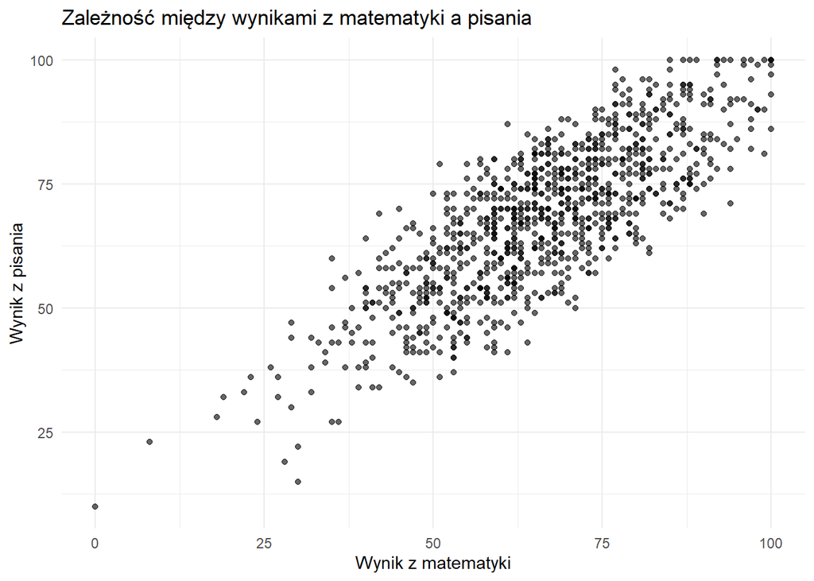

```r
ggplot(df, aes(x = math.score, y = writing.score)) +
  geom_point(alpha = 0.6) +
  labs(
    title = "Zależność między wynikami z matematyki a pisania",
    x = "Wynik z matematyki",
    y = "Wynik z pisania"
  ) +
  theme_minimal()
```

**Komentarz:** Widać zależność - nie jest to wprost proporcjonalne jednak generalnie wraz ze wzrostem wyników z czytania rosną wyniki z matematyki (dałoby się takim grubym prostopadłościanem je obrysować i dodatkowo są one gęssze na srodku - śodkowa kreska).

Widać zależność - ponownie nie jest to wprost proporcjonalne jednak generalnie wraz ze wzrostem wyników z pisania rosną wyniki z matematyki - zależność tu jest nawet wyrażniejsza niż dla czytania, po srodku rozkładu jest gęściej.